# Uber Data Analysis using Python

### Import the Essential Packages

```python
import pandas as pd
import numpy as np
import seaborn as sns
import matplotlib.pyplot as plt
import datetime
```

### Import Dataset

```python
apr = pd.read_csv("uber-raw-data-apr14.csv")
may = pd.read_csv("uber-raw-data-may14.csv")
jun = pd.read_csv("uber-raw-data-jun14.csv")
jul = pd.read_csv("uber-raw-data-jul14.csv")
aug = pd.read_csv("uber-raw-data-aug14.csv")
sep = pd.read_csv("uber-raw-data-sep14.csv")
```

### Merge Dataset

```python
df = pd.concat([apr, may, jun, jul, aug, sep], ignore_index = True)

df
```

|  | Date/Time | Lat | Lon | Base |
| --- | --- | --- | --- | --- |
| 0 | 4/1/2014 0:11:00 | 40.7690 | -73.9549 | B02512 |
| 1 | 4/1/2014 0:17:00 | 40.7267 | -74.0345 | B02512 |
| 2 | 4/1/2014 0:21:00 | 40.7316 | -73.9873 | B02512 |
| 3 | 4/1/2014 0:28:00 | 40.7588 | -73.9776 | B02512 |
| 4 | 4/1/2014 0:33:00 | 40.7594 | -73.9722 | B02512 |
| ... | ... | ... | ... | ... |
| 4534322 | 9/30/2014 22:57:00 | 40.7668 | -73.9845 | B02764 |
| 4534323 | 9/30/2014 22:57:00 | 40.6911 | -74.1773 | B02764 |
| 4534324 | 9/30/2014 22:58:00 | 40.8519 | -73.9319 | B02764 |
| 4534325 | 9/30/2014 22:58:00 | 40.7081 | -74.0066 | B02764 |
| 4534326 | 9/30/2014 22:58:00 | 40.7140 | -73.9496 | B02764 |

4534327 rows × 4 columns

### Check Missing Values

```python
df.isnull().values.any()
```

```
False
```

### Data Structure

```python
df.info()
```

```
<class 'pandas.core.frame.DataFrame'>
RangeIndex: 4534327 entries, 0 to 4534326
Data columns (total 4 columns):
 #   Column     Dtype
---  ------     -----
 0   Date/Time  object
 1   Lat        float64
 2   Lon        float64
 3   Base       object
dtypes: float64(2), object(2)
memory usage: 138.4+ MB
```

### Change the Format/Type of Date/Time to datetime

```python
df["Date/Time"] = pd.to_datetime(df['Date/Time'])

df.dtypes
```

```
Date/Time    datetime64[ns]
Lat                 float64
Lon                 float64
Base                 object
dtype: object
```

### Create Time Objects

```python
df["Time"] = df["Date/Time"].dt.time
df["Hour"] = df["Date/Time"].dt.hour
df["Date"] = df["Date/Time"].dt.date
df["Year"] = df["Date/Time"].dt.year
df["Month"] = df["Date/Time"].dt.month_name() #df["Month"] = df["Date/Time"].dt.month
df["Day"] = df["Date/Time"].dt.day
df["Wday"] = df['Date/Time'].dt.day_name() # df["Wday"] = df["Date/Time"].dt.weekday+1
df
```

|  | Date/Time | Lat | Lon | Base | Time | Hour | Date | Year | Month | Day | Wday |
| --- | --- | --- | --- | --- | --- | --- | --- | --- | --- | --- | --- |
| 0 | 2014-04-01 00:11:00 | 40.7690 | -73.9549 | B02512 | 00:11:00 | 0 | 2014-04-01 | 2014 | April | 1 | Tuesday |
| 1 | 2014-04-01 00:17:00 | 40.7267 | -74.0345 | B02512 | 00:17:00 | 0 | 2014-04-01 | 2014 | April | 1 | Tuesday |
| 2 | 2014-04-01 00:21:00 | 40.7316 | -73.9873 | B02512 | 00:21:00 | 0 | 2014-04-01 | 2014 | April | 1 | Tuesday |
| 3 | 2014-04-01 00:28:00 | 40.7588 | -73.9776 | B02512 | 00:28:00 | 0 | 2014-04-01 | 2014 | April | 1 | Tuesday |
| 4 | 2014-04-01 00:33:00 | 40.7594 | -73.9722 | B02512 | 00:33:00 | 0 | 2014-04-01 | 2014 | April | 1 | Tuesday |
| ... | ... | ... | ... | ... | ... | ... | ... | ... | ... | ... | ... |
| 4534322 | 2014-09-30 22:57:00 | 40.7668 | -73.9845 | B02764 | 22:57:00 | 22 | 2014-09-30 | 2014 | September | 30 | Tuesday |
| 4534323 | 2014-09-30 22:57:00 | 40.6911 | -74.1773 | B02764 | 22:57:00 | 22 | 2014-09-30 | 2014 | September | 30 | Tuesday |
| 4534324 | 2014-09-30 22:58:00 | 40.8519 | -73.9319 | B02764 | 22:58:00 | 22 | 2014-09-30 | 2014 | September | 30 | Tuesday |
| 4534325 | 2014-09-30 22:58:00 | 40.7081 | -74.0066 | B02764 | 22:58:00 | 22 | 2014-09-30 | 2014 | September | 30 | Tuesday |
| 4534326 | 2014-09-30 22:58:00 | 40.7140 | -73.9496 | B02764 | 22:58:00 | 22 | 2014-09-30 | 2014 | September | 30 | Tuesday |

4534327 rows × 11 columns

### Change the Order of Factors

```python
df["Wday"] = df["Wday"].astype("category")
df["Wday"] = df["Wday"].cat.reorder_categories(["Sunday","Monday","Tuesday","Wednesday","Thursday","Friday","Saturday"])

df["Month"] = df["Month"].astype("category")
df["Month"] = df["Month"].cat.reorder_categories(["April","May","June","July","August","September"])

df.dtypes
```

```
Date/Time    datetime64[ns]
Lat                 float64
Lon                 float64
Base                 object
Time                 object
Hour                  int64
Date                 object
Year                  int64
Month              category
Day                   int64
Wday               category
dtype: object
```

### Example of Calendar Package

```python
import calendar
list(calendar.day_name)
```

```
['Monday', 'Tuesday', 'Wednesday', 'Thursday', 'Friday', 'Saturday', 'Sunday']
```

```python
list(calendar.day_abbr)
```

```
['Mon', 'Tue', 'Wed', 'Thu', 'Fri', 'Sat', 'Sun']
```

```python
calendar.day_abbr[0]
```

```
'Mon'
```

### Number of Trips in a Day

```python
df.Hour.value_counts()
```

```
17    336190
18    324679
16    313400
19    294513
20    284604
21    281460
15    275466
22    241858
14    230625
13    195877
7     193094
8     190504
12    170452
23    169190
11    165703
9     159967
10    159148
6     143213
0     103836
5      83939
1      67227
4      55230
3      48287
2      45865
Name: Hour, dtype: int64
```

```python
df.groupby(["Hour"], as_index = False)["Base"].count()
```

|  | Hour | Base |
| --- | --- | --- |
| 0 | 0 | 103836 |
| 1 | 1 | 67227 |
| 2 | 2 | 45865 |
| 3 | 3 | 48287 |
| 4 | 4 | 55230 |
| 5 | 5 | 83939 |
| 6 | 6 | 143213 |
| 7 | 7 | 193094 |
| 8 | 8 | 190504 |
| 9 | 9 | 159967 |
| 10 | 10 | 159148 |
| 11 | 11 | 165703 |
| 12 | 12 | 170452 |
| 13 | 13 | 195877 |
| 14 | 14 | 230625 |
| 15 | 15 | 275466 |
| 16 | 16 | 313400 |
| 17 | 17 | 336190 |
| 18 | 18 | 324679 |
| 19 | 19 | 294513 |
| 20 | 20 | 284604 |
| 21 | 21 | 281460 |
| 22 | 22 | 241858 |
| 23 | 23 | 169190 |

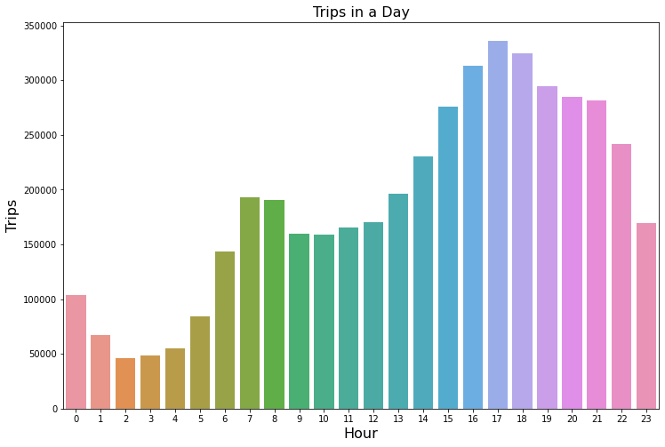

```python
plt.figure(figsize = (12,8))
# sns.barplot(x = "Hour", y = "Base", data = df.groupby(["Hour"], as_index = False)["Base"].count(), ci = None)
sns.countplot(data = df, x = "Hour")
plt.xlabel('Hour',size = 16)
plt.ylabel('Trips',size = 16)
plt.title("Trips in a Day", y = 1.00, x = 0.5, size = 16)
plt.show()
```

In the resulting visualizations, we can understand how the number of passengers fares throughout the day. We observe that the number of trips are higher in the evening around 5:00 and 6:00 PM.

### Number of Trips during Every Day of the Month

```python
df.Day.value_counts()
```

```
30    167160
12    160606
16    158921
13    156892
23    156032
9     155135
15    153726
26    153405
19    153088
25    152667
17    152524
10    152500
18    151319
29    149086
11    148860
```

[output cut: 17 more lines]

```python
df.groupby(["Day"], as_index = False)["Base"].count()
```

|  | Day | Base |
| --- | --- | --- |
| 0 | 1 | 127430 |
| 1 | 2 | 143201 |
| 2 | 3 | 142983 |
| 3 | 4 | 140923 |
| 4 | 5 | 147054 |
| 5 | 6 | 139886 |
| 6 | 7 | 143503 |
| 7 | 8 | 145984 |
| 8 | 9 | 155135 |
| 9 | 10 | 152500 |
| 10 | 11 | 148860 |
| 11 | 12 | 160606 |
| 12 | 13 | 156892 |
| 13 | 14 | 140148 |
| 14 | 15 | 153726 |
| 15 | 16 | 158921 |
| 16 | 17 | 152524 |
| 17 | 18 | 151319 |
| 18 | 19 | 153088 |
| 19 | 20 | 144179 |
| 20 | 21 | 141112 |
| 21 | 22 | 146952 |
| 22 | 23 | 156032 |
| 23 | 24 | 144169 |
| 24 | 25 | 152667 |
| 25 | 26 | 153405 |
| 26 | 27 | 145652 |
| 27 | 28 | 141157 |
| 28 | 29 | 149086 |
| 29 | 30 | 167160 |
| 30 | 31 | 78073 |

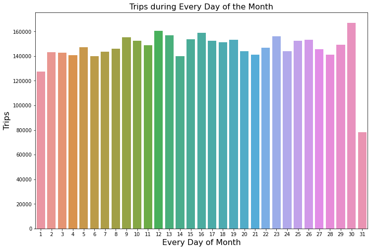

```python
plt.figure(figsize = (12,8))
#sns.barplot(x = "Day", y = "Base", data = df.groupby(["Day"], as_index = False)["Base"].count(), ci = None)
sns.countplot(data = df, x = "Day")
plt.xlabel('Every Day of Month',size = 16)
plt.ylabel('Trips',size = 16)
plt.title("Trips during Every Day of the Month", y = 1.00, x = 0.5, size = 16)
plt.show()
```

We observe from the resulting visualization that 30th of the month had the highest trips in the year.

### Number of Trips on Every Day of the Week

```python
df.Wday.value_counts()
```

```
Thursday     755145
Friday       741139
Wednesday    696488
Tuesday      663789
Saturday     646114
Monday       541472
Sunday       490180
Name: Wday, dtype: int64
```

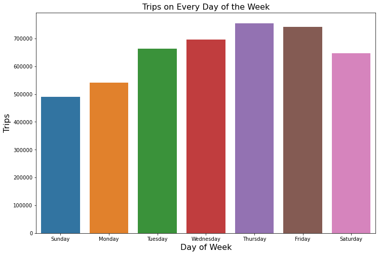

```python
plt.figure(figsize = (12,8))
#sns.barplot(x = "Wday", y = "Base", data = df.groupby(["Wday"], as_index = False)["Base"].count(), ci = None)
sns.countplot(data = df, x = "Wday")
plt.xlabel('Day of Week',size = 16)
plt.ylabel('Trips',size = 16)
plt.title("Trips on Every Day of the Week", y = 1.00, x = 0.5, size = 16)
plt.show()
```

In the output visualization, we observe that most trips were made on Thursday and Friday during the week. Potentially, people like to have meals in the restaurant on the weekend.

### Number of Trips on Each Month

```python
df.Month.value_counts()
```

```
September    1028136
August        829275
July          796121
June          663844
May           652435
April         564516
Name: Month, dtype: int64
```

```python
df.groupby(["Month"], as_index = False)["Base"].count()
```

|  | Month | Base |
| --- | --- | --- |
| 0 | April | 564516 |
| 1 | May | 652435 |
| 2 | June | 663844 |
| 3 | July | 796121 |
| 4 | August | 829275 |
| 5 | September | 1028136 |

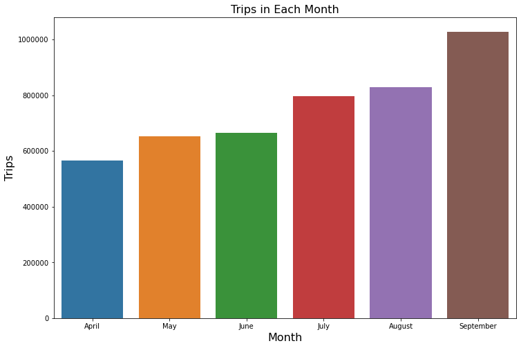

```python
plt.figure(figsize = (12,8))
#sns.barplot(x = "Month", y = "Base", data = df.groupby(["Month"], as_index = False)["Base"].count(), ci = None)
sns.countplot(data = df, x = "Month")
plt.xlabel('Month',size = 16)
plt.ylabel('Trips',size = 16)
plt.title("Trips in Each Month", y = 1.00, x = 0.5, size = 16)
plt.ticklabel_format(axis = "y", style = "plain")
plt.show()
```

In the output visualization, we observe that most trips were made during the month of September.

### Number of Trips on Day of Week during Months

```python
week_month = df.groupby(["Month","Wday"], as_index = False)["Base"].count()

week_month
```

|  | Month | Wday | Base |
| --- | --- | --- | --- |
| 0 | April | Sunday | 51251 |
| 1 | April | Monday | 60861 |
| 2 | April | Tuesday | 91185 |
| 3 | April | Wednesday | 108631 |
| 4 | April | Thursday | 85067 |
| 5 | April | Friday | 90303 |
| 6 | April | Saturday | 77218 |
| 7 | May | Sunday | 56168 |
| 8 | May | Monday | 63846 |
| 9 | May | Tuesday | 76662 |
| 10 | May | Wednesday | 89857 |
| 11 | May | Thursday | 128921 |
| 12 | May | Friday | 133991 |
| 13 | May | Saturday | 102990 |
| 14 | June | Sunday | 79656 |
| 15 | June | Monday | 94655 |
| 16 | June | Tuesday | 88134 |
| 17 | June | Wednesday | 99654 |
| 18 | June | Thursday | 115325 |
| 19 | June | Friday | 105056 |
| 20 | June | Saturday | 81364 |
| 21 | July | Sunday | 76327 |
| 22 | July | Monday | 93189 |
| 23 | July | Tuesday | 137454 |
| 24 | July | Wednesday | 147717 |
| 25 | July | Thursday | 148439 |
| 26 | July | Friday | 102735 |
| 27 | July | Saturday | 90260 |
| 28 | August | Sunday | 110246 |
| 29 | August | Monday | 91633 |
| 30 | August | Tuesday | 107124 |
| 31 | August | Wednesday | 115256 |
| 32 | August | Thursday | 124117 |
| 33 | August | Friday | 148674 |
| 34 | August | Saturday | 132225 |
| 35 | September | Sunday | 116532 |
| 36 | September | Monday | 137288 |
| 37 | September | Tuesday | 163230 |
| 38 | September | Wednesday | 135373 |
| 39 | September | Thursday | 153276 |
| 40 | September | Friday | 160380 |
| 41 | September | Saturday | 162057 |

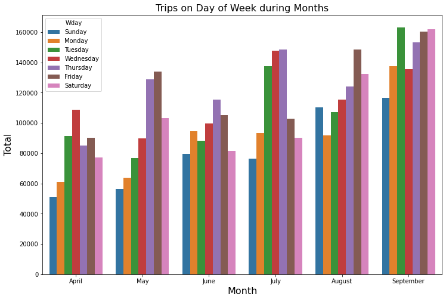

```python
#sns.catplot(x = "Month", y = "Base", hue = "Wday", data = week_month, kind = "bar", height = 8, aspect = 1.5)
plt.figure(figsize = (12,8))
sns.countplot(x = "Month", data = df, hue = "Wday")
plt.xlabel('Month',size = 16)
plt.ylabel('Total',size = 16)
plt.title("Trips on Day of Week during Months", y = 1.00, x = 0.5, size = 16)
plt.show()
```

```python
week_month = week_month.pivot_table(index = "Month", columns = "Wday", values = "Base")
week_month
```

| Wday Month | Sunday | Monday | Tuesday | Wednesday | Thursday | Friday | Saturday |
| --- | --- | --- | --- | --- | --- | --- | --- |
| April | 51251 | 60861 | 91185 | 108631 | 85067 | 90303 | 77218 |
| May | 56168 | 63846 | 76662 | 89857 | 128921 | 133991 | 102990 |
| June | 79656 | 94655 | 88134 | 99654 | 115325 | 105056 | 81364 |
| July | 76327 | 93189 | 137454 | 147717 | 148439 | 102735 | 90260 |
| August | 110246 | 91633 | 107124 | 115256 | 124117 | 148674 | 132225 |
| September | 116532 | 137288 | 163230 | 135373 | 153276 | 160380 | 162057 |

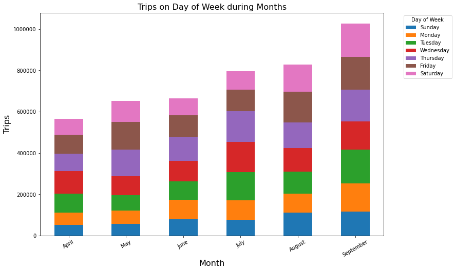

```python
# plot the pivoted dataframe

week_month.plot.bar(stacked = True, figsize = (12, 8))   # Pandas Plot Function
plt.legend(title = 'Day of Week', bbox_to_anchor = (1.05, 1), loc = 'upper left')
plt.ticklabel_format(axis = "y", style = "plain")
plt.xlabel("Month", size = 16)
plt.ylabel("Trips", size = 16)
plt.title("Trips on Day of Week during Months", y = 1.00, x = 0.5, size = 16)
plt.xticks(rotation = 30, horizontalalignment = "center")
plt.show()
```

### Number of Trips for Each Base

```python
df.groupby(["Base"], as_index = False)["Year"].count()
```

|  | Base | Year |
| --- | --- | --- |
| 0 | B02512 | 205673 |
| 1 | B02598 | 1393113 |
| 2 | B02617 | 1458853 |
| 3 | B02682 | 1212789 |
| 4 | B02764 | 263899 |

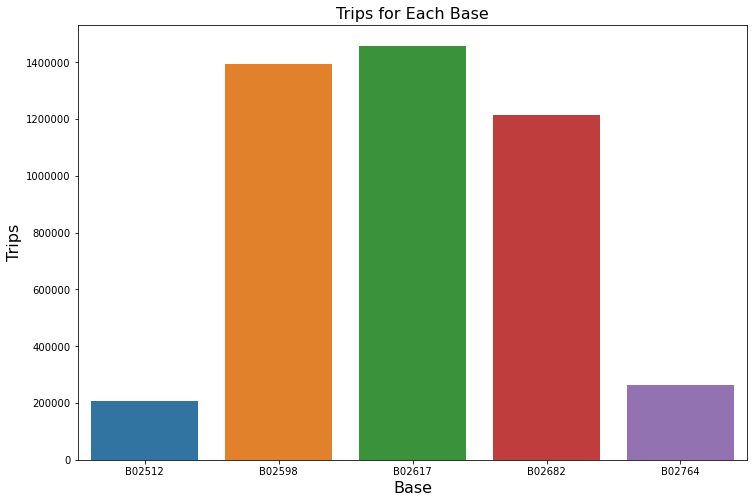

```python
plt.figure(figsize = (12,8))
#sns.barplot(x = "Base", y = "Year", data = df.groupby(["Base"], as_index = False)["Year"].count(), ci = None)
sns.countplot(x = "Base", data = df)
plt.xlabel('Base',size = 16)
plt.ylabel('Trips',size = 16)
plt.title("Trips for Each Base", y = 1.00, x = 0.5, size = 16)
plt.ticklabel_format(axis = "y", style = "plain")
plt.show()
```

In this visualization, we plot the number of trips that have been taken by the passengers from each of the bases. There are five bases in all out of which, we observe that B02617 had the highest number of trips.

### Number of Trips for Each Base during Every Month

```python
df.groupby(["Month","Base"], as_index = False)["Year"].count()
```

|  | Month | Base | Year |
| --- | --- | --- | --- |
| 0 | April | B02512 | 35536 |
| 1 | April | B02598 | 183263 |
| 2 | April | B02617 | 108001 |
| 3 | April | B02682 | 227808 |
| 4 | April | B02764 | 9908 |
| 5 | May | B02512 | 36765 |
| 6 | May | B02598 | 260549 |
| 7 | May | B02617 | 122734 |
| 8 | May | B02682 | 222883 |
| 9 | May | B02764 | 9504 |
| 10 | June | B02512 | 32509 |
| 11 | June | B02598 | 242975 |
| 12 | June | B02617 | 184460 |
| 13 | June | B02682 | 194926 |
| 14 | June | B02764 | 8974 |
| 15 | July | B02512 | 35021 |
| 16 | July | B02598 | 245597 |
| 17 | July | B02617 | 310160 |
| 18 | July | B02682 | 196754 |
| 19 | July | B02764 | 8589 |
| 20 | August | B02512 | 31472 |
| 21 | August | B02598 | 220129 |
| 22 | August | B02617 | 355803 |
| 23 | August | B02682 | 173280 |
| 24 | August | B02764 | 48591 |
| 25 | September | B02512 | 34370 |
| 26 | September | B02598 | 240600 |
| 27 | September | B02617 | 377695 |
| 28 | September | B02682 | 197138 |
| 29 | September | B02764 | 178333 |

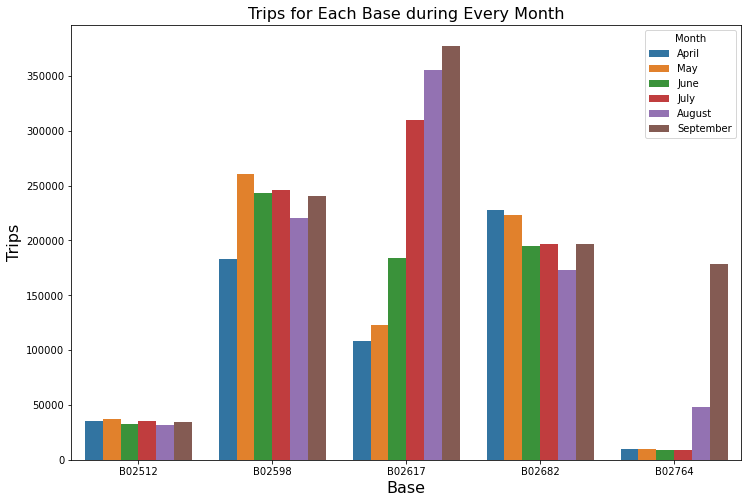

```python
#sns.catplot(x = "Base", y = "Year", hue = "Month", data = df.groupby(["Month","Base"], as_index = False)["Year"].count(), kind = "bar", height = 8, aspect = 1.5)
plt.figure(figsize = (12,8))
sns.countplot(x = "Base", data = df, hue = "Month")
plt.xlabel('Base',size = 16)
plt.ylabel('Trips',size = 16)
plt.title("Trips for Each Base during Every Month", y = 1.00, x = 0.5, size = 16)
plt.show()
```

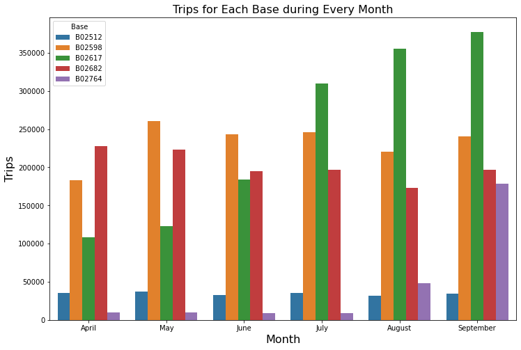

```python
plt.figure(figsize = (12,8))
sns.countplot(x = "Month", data = df, hue = "Base")
plt.xlabel('Month',size = 16)
plt.ylabel('Trips',size = 16)
plt.title("Trips for Each Base during Every Month", y = 1.00, x = 0.5, size = 16)
plt.show()
```

### Number of Trips for Each Base during Day of Week Every Month

```python
df.groupby(["Wday","Base"], as_index = False)["Year"].count()
```

|  | Wday | Base | Year |
| --- | --- | --- | --- |
| 0 | Sunday | B02512 | 20490 |
| 1 | Sunday | B02598 | 146652 |
| 2 | Sunday | B02617 | 164452 |
| 3 | Sunday | B02682 | 126511 |
| 4 | Sunday | B02764 | 32075 |
| 5 | Monday | B02512 | 25460 |
| 6 | Monday | B02598 | 163542 |
| 7 | Monday | B02617 | 176416 |
| 8 | Monday | B02682 | 143372 |
| 9 | Monday | B02764 | 32682 |
| 10 | Tuesday | B02512 | 31670 |
| 11 | Tuesday | B02598 | 202378 |
| 12 | Tuesday | B02617 | 214167 |
| 13 | Tuesday | B02682 | 176198 |
| 14 | Tuesday | B02764 | 39376 |
| 15 | Wednesday | B02512 | 32929 |
| 16 | Wednesday | B02598 | 216644 |
| 17 | Wednesday | B02617 | 222669 |
| 18 | Wednesday | B02682 | 189863 |
| 19 | Wednesday | B02764 | 34383 |
| 20 | Thursday | B02512 | 35032 |
| 21 | Thursday | B02598 | 235157 |
| 22 | Thursday | B02617 | 240216 |
| 23 | Thursday | B02682 | 205091 |
| 24 | Thursday | B02764 | 39649 |
| 25 | Friday | B02512 | 33319 |
| 26 | Friday | B02598 | 229908 |
| 27 | Friday | B02617 | 234379 |
| 28 | Friday | B02682 | 201594 |
| 29 | Friday | B02764 | 41939 |
| 30 | Saturday | B02512 | 26773 |
| 31 | Saturday | B02598 | 198832 |
| 32 | Saturday | B02617 | 206554 |
| 33 | Saturday | B02682 | 170160 |
| 34 | Saturday | B02764 | 43795 |

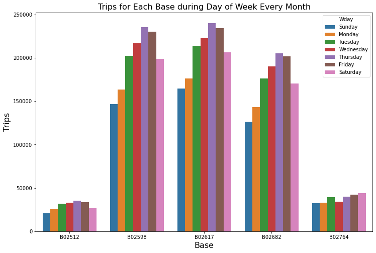

```python
#sns.catplot(x = "Base", y = "Year", hue = "Wday", data = df.groupby(["Wday","Base"], as_index = False)["Year"].count(), kind = "bar", height = 8, aspect = 1.5)
plt.figure(figsize = (12,8))
sns.countplot(x = "Base", data = df, hue = "Wday")
plt.xlabel('Base',size = 16)
plt.ylabel('Trips',size = 16)
plt.title("Trips for Each Base during Day of Week Every Month", y = 1.00, x = 0.5, size = 16)
plt.show()
```

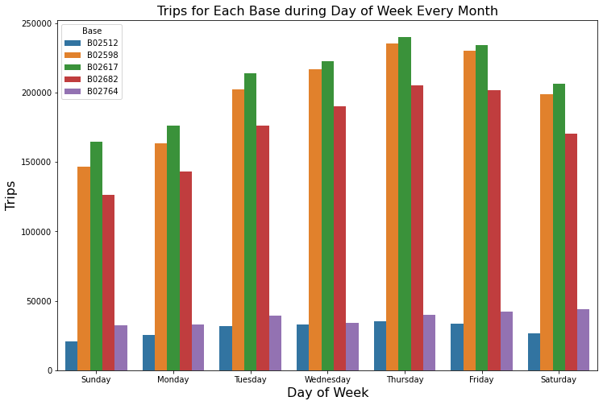

```python
plt.figure(figsize = (12,8))
sns.countplot(x = "Wday", data = df, hue = "Base")
plt.xlabel('Day of Week',size = 16)
plt.ylabel('Trips',size = 16)
plt.title("Trips for Each Base during Day of Week Every Month", y = 1.00, x = 0.5, size = 16)
plt.show()
```

Furthermore, B02617 base had the highest number of trips in the month September. Thursday observed highest trips in the three bases – B02598, B02617, B02682.

## Heatmap

```python
# The matplotlib basemap toolkit is a library for plotting 2D data on maps in Python

from mpl_toolkits.basemap import Basemap
from matplotlib import cm # Colormap
```

### Heatmap by Hour and Day

```python
hour_day = df.groupby(["Hour","Day"], as_index = False)["Base"].count().pivot_table(index = "Hour", columns = "Day", values = "Base")

hour_day
```

| Day Hour | 1 | 2 | 3 | 4 | 5 | 6 | 7 | 8 | 9 | 10 | ... | 22 | 23 | 24 | 25 | 26 | 27 | 28 | 29 | 30 | 31 |
| --- | --- | --- | --- | --- | --- | --- | --- | --- | --- | --- | --- | --- | --- | --- | --- | --- | --- | --- | --- | --- | --- |
| 0 | 3247 | 2480 | 3415 | 2944 | 2786 | 4623 | 3715 | 2882 | 2708 | 3351 | ... | 2852 | 2605 | 3277 | 2442 | 3887 | 5304 | 4224 | 2732 | 2439 | 2209 |
| 1 | 1982 | 1600 | 2176 | 1718 | 1567 | 2932 | 2326 | 1672 | 1757 | 2167 | ... | 1662 | 1608 | 2090 | 1525 | 3123 | 3712 | 2711 | 1862 | 1547 | 1407 |
| 2 | 1284 | 1109 | 1434 | 1217 | 1047 | 1902 | 1533 | 1147 | 1246 | 1495 | ... | 1207 | 1163 | 1480 | 1098 | 2087 | 2407 | 1894 | 1442 | 1135 | 1107 |
| 3 | 1331 | 1442 | 1489 | 1449 | 1278 | 1599 | 1622 | 1509 | 1501 | 1466 | ... | 1503 | 1465 | 1520 | 1472 | 1840 | 2098 | 1846 | 1717 | 1436 | 935 |
| 4 | 1458 | 1897 | 1578 | 1737 | 1648 | 1584 | 1793 | 1921 | 1911 | 1614 | ... | 1984 | 1994 | 1825 | 1972 | 1770 | 1759 | 1916 | 1990 | 1864 | 788 |
| 5 | 2171 | 2861 | 2437 | 2623 | 2958 | 2201 | 2464 | 3282 | 3227 | 2652 | ... | 3222 | 3182 | 2802 | 3029 | 2389 | 2380 | 2846 | 3127 | 3264 | 1012 |
| 6 | 3717 | 5002 | 4318 | 4687 | 4919 | 3705 | 4172 | 5528 | 5910 | 4757 | ... | 5315 | 5315 | 4565 | 5465 | 3838 | 3609 | 4368 | 5329 | 5850 | 1590 |
| 7 | 5470 | 6646 | 5775 | 6146 | 6379 | 4846 | 5649 | 7474 | 7720 | 6168 | ... | 6981 | 7027 | 6111 | 7775 | 5282 | 5023 | 5828 | 6992 | 7735 | 2201 |
| 8 | 5376 | 6420 | 5482 | 5799 | 6580 | 5009 | 5459 | 7472 | 7641 | 6271 | ... | 6995 | 6564 | 6024 | 7214 | 5169 | 5142 | 5759 | 6825 | 7760 | 2442 |
| 9 | 4688 | 4795 | 4732 | 4814 | 5616 | 4482 | 4706 | 5770 | 5983 | 5165 | ... | 5305 | 5271 | 5242 | 6097 | 4913 | 4855 | 5283 | 5586 | 6168 | 2564 |
| 10 | 4680 | 4886 | 4864 | 4822 | 5225 | 4891 | 4982 | 5368 | 5500 | 5070 | ... | 5362 | 5159 | 5027 | 5533 | 5169 | 5299 | 5332 | 5321 | 6084 | 2607 |
| 11 | 4811 | 5067 | 5162 | 5067 | 5097 | 5264 | 5266 | 5433 | 5542 | 5513 | ... | 5452 | 5424 | 5408 | 5604 | 5293 | 5829 | 5616 | 5256 | 6202 | 2823 |
| 12 | 5018 | 5278 | 5462 | 5289 | 5129 | 5528 | 5455 | 5576 | 5607 | 5617 | ... | 5614 | 5612 | 5318 | 5805 | 5494 | 5943 | 5600 | 5331 | 6543 | 2997 |
| 13 | 5887 | 5801 | 6189 | 6273 | 5780 | 6378 | 6315 | 6424 | 6540 | 6631 | ... | 6458 | 6362 | 6078 | 6327 | 6288 | 6957 | 6241 | 6419 | 7385 | 3325 |
| 14 | 7050 | 7021 | 7327 | 7307 | 7072 | 7353 | 7418 | 7356 | 7997 | 7739 | ... | 7470 | 7733 | 7207 | 7437 | 7419 | 7654 | 7480 | 7760 | 8554 | 4176 |
| 15 | 8033 | 8581 | 8991 | 8678 | 8453 | 8751 | 8624 | 8910 | 9360 | 9772 | ... | 9323 | 9498 | 8857 | 8885 | 8972 | 8969 | 8753 | 9416 | 10456 | 5177 |
| 16 | 8760 | 10267 | 10472 | 9661 | 9770 | 9615 | 10585 | 10007 | 10419 | 11256 | ... | 10776 | 10162 | 10567 | 10114 | 10057 | 9980 | 9877 | 10316 | 11769 | 5483 |
| 17 | 9661 | 11301 | 10665 | 10550 | 10887 | 10130 | 11185 | 10871 | 12116 | 12112 | ... | 11175 | 10536 | 10982 | 10699 | 10895 | 10032 | 10175 | 11333 | 12378 | 5415 |
| 18 | 8727 | 11326 | 11433 | 10458 | 10324 | 9437 | 10767 | 9874 | 11677 | 11121 | ... | 10077 | 11044 | 9954 | 10889 | 11087 | 9425 | 9322 | 10598 | 12807 | 5450 |
| 19 | 8146 | 9654 | 9765 | 9296 | 9582 | 8575 | 9674 | 8964 | 9979 | 9800 | ... | 9164 | 11578 | 9251 | 9212 | 10314 | 8447 | 8435 | 9476 | 11249 | 5001 |
| 20 | 7448 | 8903 | 9158 | 8508 | 9512 | 8286 | 8862 | 8768 | 9061 | 9876 | ... | 8920 | 11678 | 9379 | 8945 | 10009 | 8077 | 8479 | 9439 | 11060 | 4923 |
| 21 | 7960 | 8506 | 8646 | 8804 | 9785 | 8734 | 8692 | 8528 | 8806 | 9403 | ... | 8599 | 10544 | 9022 | 9702 | 10666 | 8707 | 8097 | 9287 | 10246 | 5171 |
| 22 | 6397 | 7111 | 7246 | 7852 | 9020 | 8000 | 7337 | 6917 | 7637 | 7886 | ... | 6911 | 8821 | 7636 | 8687 | 9688 | 7868 | 6519 | 7122 | 8433 | 5244 |
| 23 | 4128 | 5247 | 4767 | 5224 | 6640 | 6061 | 4902 | 4331 | 5290 | 5598 | ... | 4625 | 5687 | 4547 | 6739 | 7756 | 6176 | 4556 | 4410 | 4796 | 4026 |

24 rows × 31 columns

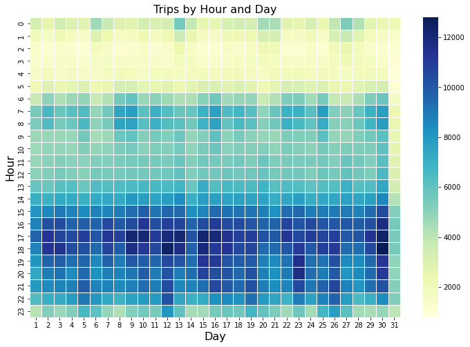

```python
plt.figure(figsize = (12,8))
sns.heatmap(hour_day, cmap = cm.YlGnBu, linewidth = .5) # Using the Seaborn Heatmap Function
plt.xlabel('Day',size = 16)
plt.ylabel('Hour',size = 16)
plt.title("Trips by Hour and Day", y = 1.00, x = 0.5, size = 16)
plt.show()
```

We see that the number of trips in increasing throughout the day, with a peak demand in the evening between 16:00 and 18:00.

It corresponds to the time where employees finish their work and go home.

### Heatmap by Hour and Weekday

```python
hour_wday = df.groupby(["Hour","Wday"], as_index = False)["Base"].count().pivot_table(index = "Hour", columns = "Wday", values = "Base")

hour_wday
```

| Wday Hour | Sunday | Monday | Tuesday | Wednesday | Thursday | Friday | Saturday |
| --- | --- | --- | --- | --- | --- | --- | --- |
| 0 | 32877 | 6436 | 6237 | 7644 | 9293 | 13716 | 27633 |
| 1 | 23015 | 3737 | 3509 | 4324 | 5290 | 8163 | 19189 |
| 2 | 15436 | 2938 | 2571 | 3141 | 3719 | 5350 | 12710 |
| 3 | 10597 | 6232 | 4494 | 4855 | 5637 | 6930 | 9542 |
| 4 | 6374 | 9640 | 7548 | 7511 | 8505 | 8806 | 6846 |
| 5 | 6169 | 15032 | 14241 | 13794 | 14169 | 13450 | 7084 |
| 6 | 6596 | 23746 | 26872 | 26943 | 27065 | 23412 | 8579 |
| 7 | 8728 | 31159 | 36599 | 36495 | 37038 | 32061 | 11014 |
| 8 | 12128 | 29265 | 33934 | 33826 | 35431 | 31509 | 14411 |
| 9 | 16401 | 22197 | 25023 | 25635 | 27812 | 25230 | 17669 |
| 10 | 19839 | 20288 | 23676 | 24696 | 25877 | 24176 | 20596 |
| 11 | 22856 | 20333 | 23679 | 24963 | 25966 | 25188 | 22718 |
| 12 | 23911 | 20488 | 23850 | 25533 | 26465 | 25907 | 24298 |
| 13 | 26417 | 23385 | 29075 | 29183 | 30840 | 30341 | 26636 |
| 14 | 28151 | 28157 | 34846 | 35148 | 36699 | 36206 | 31418 |
| 15 | 31112 | 32744 | 41338 | 43388 | 44442 | 43673 | 38769 |
| 16 | 33038 | 38770 | 48667 | 50684 | 50560 | 48169 | 43512 |
| 17 | 31521 | 42023 | 55500 | 55637 | 56704 | 51961 | 42844 |
| 18 | 28291 | 37000 | 50186 | 52732 | 55825 | 54762 | 45883 |
| 19 | 25948 | 34159 | 44789 | 47017 | 51907 | 49595 | 41098 |
| 20 | 25076 | 32849 | 44661 | 47772 | 51990 | 43542 | 38714 |
| 21 | 23967 | 28925 | 39913 | 44553 | 51953 | 48323 | 43826 |
| 22 | 19566 | 20158 | 27712 | 32868 | 44194 | 49409 | 47951 |
| 23 | 12166 | 11811 | 14869 | 18146 | 27764 | 41260 | 43174 |

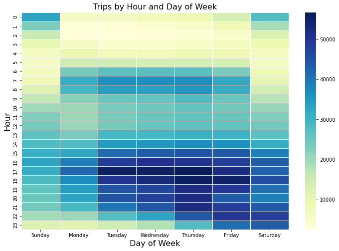

```python
plt.figure(figsize = (12,8))
sns.heatmap(hour_wday, cmap = cm.YlGnBu, linewidth = .5)
plt.xlabel('Day of Week',size = 16)
plt.ylabel('Hour',size = 16)
plt.title("Trips by Hour and Day of Week", y = 1.00, x = 0.5, size = 16)
plt.show()
```

We can see that on working days (From Monday to Friday) the number of trips is higher from 16:00 to 21:00. It shows even better what we said from the first heatmap.

On Friday the number of trips remains high until 23:00 and continues on early Saturday. It corresponds to the time where people come out from work, then go out for dinner or drink before the weekend.

We can notice the same pattern on Saturday, people tend to go out at night, the number of trips remains on high until early Sunday.

### Heatmap by Day and Month

```python
day_month = df.groupby(["Day","Month"], as_index = False)["Base"].count().pivot_table(index = "Day", columns = "Month", values = "Base")

day_month
```

| Month Day | April | May | June | July | August | September |
| --- | --- | --- | --- | --- | --- | --- |
| 1 | 14546 | 23375 | 15967 | 21228 | 32353 | 19961 |
| 2 | 17474 | 24235 | 17503 | 26480 | 28678 | 28831 |
| 3 | 20701 | 22234 | 22674 | 21597 | 23146 | 32631 |
| 4 | 26714 | 13918 | 22831 | 14148 | 24952 | 38360 |
| 5 | 19521 | 17859 | 28371 | 10890 | 28094 | 42319 |
| 6 | 13445 | 19300 | 24683 | 11443 | 30495 | 40520 |
| 7 | 19550 | 21891 | 20889 | 18280 | 32759 | 30134 |
| 8 | 16188 | 27513 | 15749 | 25763 | 30411 | 30360 |
| 9 | 16843 | 26385 | 23244 | 27817 | 26286 | 34560 |
| 10 | 20041 | 22550 | 22874 | 30541 | 20584 | 35910 |
| 11 | 20420 | 14901 | 25716 | 28752 | 22632 | 36439 |
| 12 | 18170 | 17470 | 29844 | 25936 | 29646 | 39540 |
| 13 | 12112 | 19498 | 31207 | 21082 | 29788 | 43205 |
| 14 | 12674 | 22218 | 19327 | 27350 | 30457 | 28122 |
| 15 | 20641 | 26301 | 14511 | 33845 | 28974 | 29454 |
| 16 | 17717 | 32493 | 17778 | 28607 | 26234 | 36092 |
| 17 | 20973 | 22294 | 21807 | 30710 | 21209 | 35531 |
| 18 | 18074 | 16508 | 24647 | 29860 | 21956 | 40274 |
| 19 | 14602 | 18315 | 28594 | 25726 | 24834 | 41017 |
| 20 | 11017 | 20860 | 24271 | 21212 | 27955 | 38864 |
| 21 | 13162 | 23508 | 19940 | 23578 | 32304 | 28620 |
| 22 | 16975 | 26802 | 16322 | 29029 | 29512 | 28312 |
| 23 | 20346 | 26465 | 17735 | 34073 | 27097 | 30316 |
| 24 | 23352 | 14651 | 20779 | 32050 | 22036 | 31301 |
| 25 | 25095 | 10841 | 26460 | 29975 | 22093 | 38203 |
| 26 | 24925 | 10202 | 28516 | 27708 | 24550 | 37504 |
| 27 | 14677 | 17004 | 24895 | 22590 | 27018 | 39468 |
| 28 | 15475 | 22240 | 21208 | 23981 | 28597 | 29656 |
| 29 | 22835 | 24930 | 17107 | 27589 | 27424 | 29201 |
| 30 | 36251 | 24413 | 18395 | 30740 | 23930 | 33431 |
| 31 | 0 | 21261 | 0 | 33541 | 23271 | 0 |

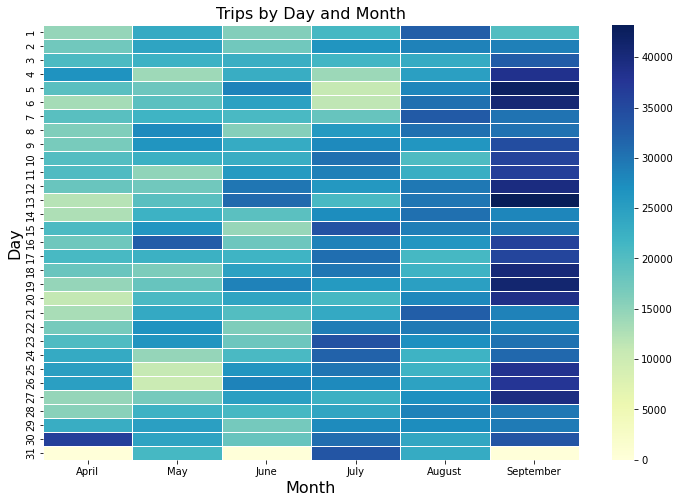

```python
plt.figure(figsize = (12,8))
sns.heatmap(day_month, cmap = cm.YlGnBu, linewidth = .5)
plt.xlabel('Month',size = 16)
plt.ylabel('Day',size = 16)
plt.title("Trips by Day and Month", y = 1.00, x = 0.5, size = 16)
plt.show()
```

We observe that the number of trips increases each month, we can say that from April to September 2014, Uber was in a continuous improvement process.

We can notice from the visualization a dark spot, it corresponds to the 30 April. The number of trips that day was extreme compared to the rest of the month.

Unfortunatly we have not been able to find any factual information to explain the pulse. A successful marketing strategy can be assumed to be in place that days. So as the analysis go on we consider that day an outliner.

### Heatmap by Month and Day of Week

```python
wday_month = df.groupby(["Wday","Month"], as_index = False)["Base"].count().pivot_table(index = "Month", columns = "Wday", values = "Base")

wday_month
```

| Wday Month | Sunday | Monday | Tuesday | Wednesday | Thursday | Friday | Saturday |
| --- | --- | --- | --- | --- | --- | --- | --- |
| April | 51251 | 60861 | 91185 | 108631 | 85067 | 90303 | 77218 |
| May | 56168 | 63846 | 76662 | 89857 | 128921 | 133991 | 102990 |
| June | 79656 | 94655 | 88134 | 99654 | 115325 | 105056 | 81364 |
| July | 76327 | 93189 | 137454 | 147717 | 148439 | 102735 | 90260 |
| August | 110246 | 91633 | 107124 | 115256 | 124117 | 148674 | 132225 |
| September | 116532 | 137288 | 163230 | 135373 | 153276 | 160380 | 162057 |

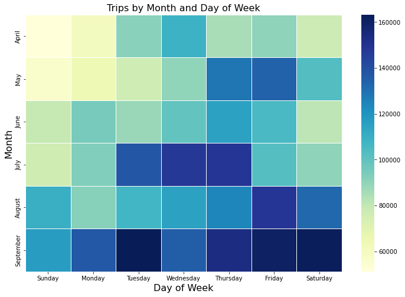

```python
plt.figure(figsize = (12,8))
sns.heatmap(wday_month, cmap = cm.YlGnBu, linewidth = .5)
plt.xlabel('Day of Week',size = 16)
plt.ylabel('Month',size = 16)
plt.title("Trips by Month and Day of Week", y = 1.00, x = 0.5, size = 16)
plt.show()
```

## Spatial Visualization

### Scatter visualization

Reduce the need in computational power by dropping the duplicates in Latitude and Longitude

```python
# Setting up the limits

top, bottom, left, right = 41, 40.55, -74.3, -73.6
```

```python
df_reduced = df.drop_duplicates(['Lat','Lon'])
```

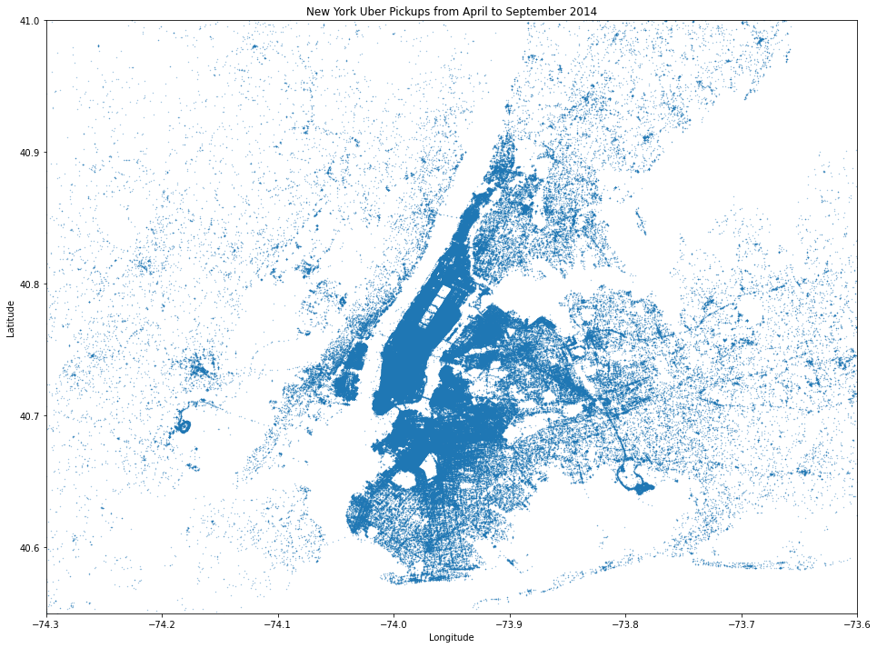

```python
plt.figure(figsize = (16, 12))
plt.ylim(top = top, bottom = bottom)
plt.xlim(left = left, right = right)

# Extracting the Longitude and Latitude of each pickup in our reduced dataset
plt.plot(df_reduced['Lon'], df_reduced['Lat'], '.', ms = 0.8, alpha = 0.5)

plt.xlabel('Longitude')
plt.ylabel('Latitude')
plt.title('New York Uber Pickups from April to September 2014')
plt.show()
```

### Heatmap Visualization

This visualization is more demanding in computational power, since we can't use the reduce dataset if we want to get the number of pickups in the heatmap. We will use Basemap to create the spacial heatmap.

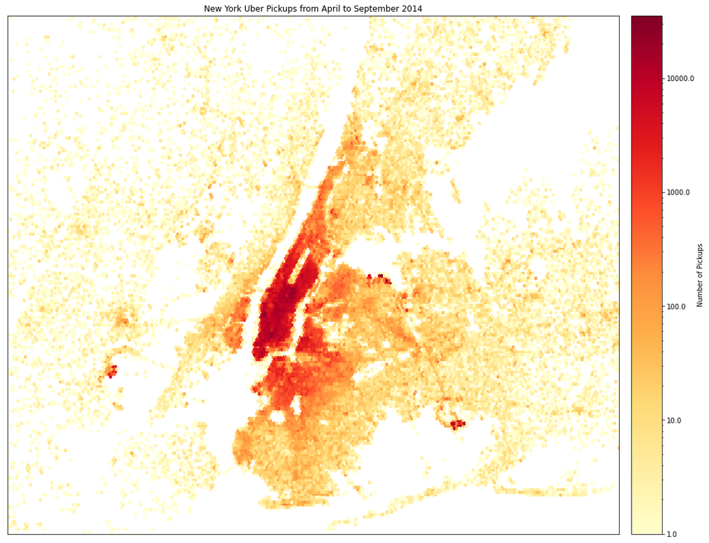

```python
#Extracting the Longitude and Latitude of each pickup in our dataset

Longitudes = df['Lon'].values
Latitudes  = df['Lat'].values

plt.figure(figsize = (18, 14))
plt.title('New York Uber Pickups from April to September 2014')

# https://matplotlib.org/basemap/api/basemap_api.html
map = Basemap(projection = 'merc', urcrnrlat = top, llcrnrlat = bottom, llcrnrlon = left, urcrnrlon = right)
x, y = map(Longitudes, Latitudes)
map.hexbin(x, y, gridsize = 1000, bins = 'log', cmap = cm.YlOrRd)
map.colorbar(location = 'right', format = '%.1f', label = 'Number of Pickups')
```

From our spacial visualization we observe that:

- Most of Uber's trips in New York are made from Midtown to Lower Manhattan.
- Followed by Upper Manhattan and the Heights of Brooklyn.
- Lastly Jersey City and the rest of Brooklyn.

We see some brighter spots in our heatmap, corresponding to :

- LaGuardia Airport in East Elmhurst.
- John F. Kennedy International Airport.
- Newark Liberty International Airport.

We know that many airports have specific requirements about where customers can be picked up by vehicles on the Uber platform. We can assume that these three airports have them, since they represent a big part of uber's business in new york.